# The Normal Distribution

Stat 2510: Statistical Methods

2026

## Normal Distributions

In this section students will:

1. Graph a normal curve
2. Identify the properties of a normal distribution
3. Apply the empirical rule to solve real-world applications
4. Given mean and standard deviation, convert raw data to z-scores
5. Given mean and standard deviation, convert z-scores to raw data
6. Compute probabilities of the normal distribution to solve real-world applications

## Properties of Continuous Probability Distributions

The graph of a continuous probability distribution is a curve. The probability of interest is represented by the area under the curve.

The curve is called the **probability density function** (**pdf**). Function notation is used ($f(x)$) to represent the curve. $f(x)$ is the function that corresponds to the graph; we use the density function $f(x)$ to draw the graph of a probability distribution.

**Area under the curve** is given by a different (related) function called the **cumulative distribution function** (**cdf**). The cumulative distribution function is used to find probabilities as areas under the curve.

- Outcomes are measured, not counted
- The entire area under the curve and above the $x$-axis is equal to 1
- Probability is found for *intervals* of $x$ values rather than for individual $x$ values
- $P(a<X<b)$ is the probability that the random variable $X$ is in the interval between the values $a$ and $b$
- $P(x=c)=0$. The probability that $x$ takes on any single individual value is zero. The area below the curve, above the $x$-axis, and between $x=c$ and $x=c$ has no width, and therefore no area (area=0). Since probabilities are areas under curves, the probability is also zero (tldr: the area under the curve at a single point does not exist and the area is equal to zero)
- $P(a<X<b)=P(a\le X\le b)$; they are the same because probability is equal to area

## Introduction to Normal

The normal, a continuous distribution, is the most important of all the distributions. It is widely used and even more widely abused.

Its graph is bell-shaped. You see the bell curve in almost all disciplines. Two important points about this curve are:

1. The curve is symmetrical about a vertical line drawn through the mean, $\mu$
2. The area under the curve must equal one

The normal distribution has two parameters (two numerical descriptive measures), the mean $\mu$ and the standard deviation $\sigma$.

If $X$ is a quantity to be measured that has a normal distribution with mean, $\mu$, and standard deviation, $\sigma$, we designate this by writing $X\sim N(\mu,\sigma)$.

The cumulative distribution function is $P(X<x)$. It is calculated either by a calculator or a computer, or it is looked up in a table.

## Terms

The normal distribution has two parameters: mean ($\mu$) and standard deviation ($\sigma$).

$$\text{Shorthand notation: }X \sim
N(\mu,\sigma)$$

The probability density function (pdf) for a normal distribution is:

$$f(x)=\frac{1}{\sqrt{2\pi\sigma^2}}e^{-\frac{(x-\mu)^2}{2\sigma^2}}$$

To use this, you would have to use calculus but we will not have to, there is another (easier) way to calculate probabilities.

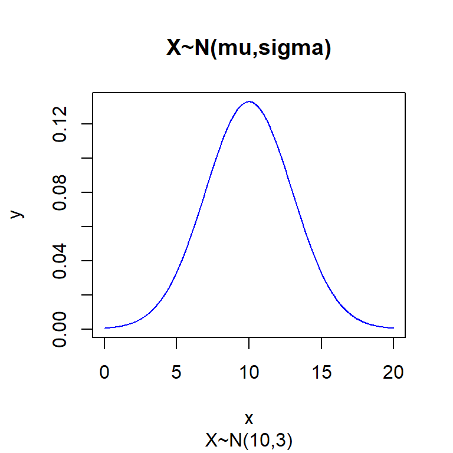

## Standard Normal Distribution

The standard normal distribution is a normal distribution of standardized values, called $z$-scores. The $z$-scores are measured in units of the standard deviation. It is always centered at 0 and always has a standard deviation of 1, thus

$$Z \sim N(0,1)$$

**$Z$-score logistics**

$z$-scores are the number of standard deviations the value is in relation to the mean. If $z=-1$, that is one standard deviation *below* the mean, if $z=1$, that is one standard deviation *above* the mean. Values of $x$ that are smaller than the mean will have negative $z$-scores, $x$ values that are larger than the mean will have positive $z$-scores. If $x$ is equal to the mean, then it has a $z$-score of 0. $Z$-scores allow comparison of data that originate on different scales

The Empirical Rule is derived from the normal distribution:

68% of observations are within the interval $\overline{X}\pm 1s$  
95% of observations are within the interval $\overline{X}\pm 2s$  
99.7% of observations are within the interval $\overline{X}\pm 3s$

One of the examples from the Standard Normal examples will show the area between -1 and 1

## Standard Normal Graph

With mean $\mu=0$ and standard deviation $\sigma=1$, thus

$$Z \sim N(0,1)$$

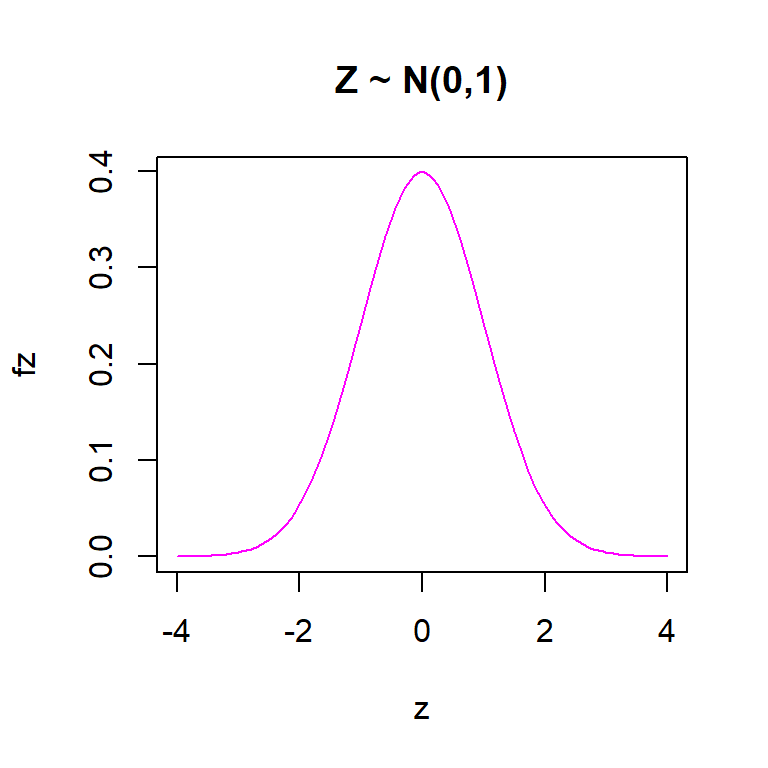

## Standard normal distribution formulas and probabilities

If $X\sim N(\mu,\sigma)$ then

$$z=\frac{X-\mu}{\sigma}$$
and
$$X=z_0\sigma+\mu$$

## Calculating (finding) probabilities with the table

1. Calculate the Z-score: Use the formula $z=\frac{x-\mu}{\sigma}$ (where $x$ is the value of interest, $\mu$ is the mean, and $\sigma$ is the standard deviation).
2. Locate the Z-score: Find the first two digits (example: 1.2) in the left-hand column and the second decimal digit (example: 0.04) in the top row.
3. Find the Intersection: The value where the row and column intersect is the probability, which represents the area to the left of that Z-score.
4. Interpret the Result
   1. Less than ($P(Z<z)$): Use the table value directly
   2. Greater than ($P(Z>z$)): Subtract the table value from 1 ($P(Z>z)=1-P(Z<z)$).
   3. Between two scores: Find the area for both, then subtract the smaller area from the larger ($P(Z<z_{larger})-P(Z<z_{smaller})$)

**To find a z-score associated with a probability (percent)**

1. Find the *left area/tail probability* and find it *inside* the table
2. Use the intersection on the table to find its z-score

## Standard Normal Example

With $z$-scores:

$P(Z<1)$  
$P(Z>1)$  
$P(Z<-1)$  
$P(Z>-1)$  
$P(-1<Z<1)$  
$z$-score for top 1%: $P(Z>z_0)=0.01$  
$z$-score for $Q1$: $P(Z<z_0)=0.25$  
$z$-score for $Q3$: $P(Z<z_0)=0.75$

## Standard Normal Solutions

With $z$-scores:

$P(Z<1)=0.8413447$

$P(Z>1)=1-0.8413447=0.1586553$

$P(Z<-1)=0.1586553$

$P(Z>-1)=1-0.1586553=0.8413447$

$P(-1<Z<1)=0.8413447-0.1586553=0.6826895$

$z$-score for top 1%: $P(Z>z_0)=0.01 \Rightarrow z_0=2.327$

$z$-score for $Q1$: $P(Z<z_0)=0.25 \Rightarrow z_0=-0.675$

$z$-score for $Q3$: $P(Z<z_0)=0.75 \Rightarrow z_0=0.675$

**Empirical Rule derivation**  
$P(-1<Z<1)=0.8413447-0.1586553=0.6826895$

$P(-2<Z<2)=0.9772499-0.0227501=0.9544997$

$P(-3<Z<3)=0.9986501-0.0013499=0.9973002$

## Normal Example I

Suppose a pizza company has a rule that your pizza must be 16” or you will receive it for free. Assume pizza sizes follow a normal distribution. At a restaurant, the mean size for pizza is 16.3” with standard deviation of 0.2”. Find the following:

- What is the probability that your pizza will be free?
- What is the probability your pizza will be over 16.5”?
- What is the probability a pizza will be between 15.95” and 16.63”?
- What is the size of pizza that represents the biggest 7% of pizzas?
- What is the size of pizza that represents Q1 (25th percentile)?
- What is the size of pizza that represents Q3 (75th percentile)?
- What is the IQR for pizza size?

## What is normal? (bahaha)

[I’m normal](https://www.youtube.com/watch?v=VS4jZn0mr3A&ab_channel=TheSpongeFanatic)

[Not normal](https://www.youtube.com/watch?v=Mf81lCWe50A&ab_channel=DreadHeadMike)

[Spongeboob](https://www.youtube.com/watch?v=v0xZ6qq73qE&ab_channel=NauticalNovice)

There is no solution for a normal Spongebob…he will be crazy forever…forever…forever…